# Energy Analytics - Load Demand Forecasting

Jason Darsono

2023-03-10

## I. Initial Setup & Packages

```r
knitr::opts_chunk$set(echo = TRUE,  cache = TRUE)

library(tidyverse)
library(patchwork)
library(forecast)
```

```r
library(tseries)
library(ggplot2)
library(dplyr)
library(car)
library(lubridate)
library(neuralnet)
```

## II. Data Exploration & Pre-processing

### A. Load dataset

Note: Data has been merged and processed in Excel separately.

```r
data <- read_csv("data_2023-03-22.csv")
data <- filter(data, !is.na(date))
head(data)
```

```
## # A tibble: 6 × 22
##   date       temp_london_00h temp_london_06h temp_london_12h temp_london_18h
##   <date>               <dbl>           <dbl>           <dbl>           <dbl>
## 1 2019-01-01          5.79             4.80             9.21            4.69
## 2 2019-01-02          1.56             0.601            5.28            1.95
## 3 2019-01-03          1.52             1.00             4.13            2.01
## 4 2019-01-04          0.823            0.905            3.35            1.76
## 5 2019-01-05          0.0564          -0.452            4.43            2.91
## 6 2019-01-06          1.91             4.10             9.40            7.57
## # ℹ 17 more variables: temp_bristol_00h <dbl>, temp_bristol_06h <dbl>,
## #   temp_bristol_12h <dbl>, temp_bristol_18h <dbl>, temp_leeds_00h <dbl>,
## #   temp_leeds_06h <dbl>, temp_leeds_12h <dbl>, temp_leeds_18h <dbl>,
## #   sunshine_london <dbl>, sunshine_bristol <dbl>, sunshine_leeds <dbl>,
## #   total_demand <dbl>, day_of_week <chr>, weekend <dbl>, holiday <dbl>,
## #   stringency <dbl>, avg_gas_index <dbl>
```

### B. Visualise data

Temperature seems to have non-linear relationship with load demand. Therefore, we may want to use 2nd order polynomial to capture this relationship

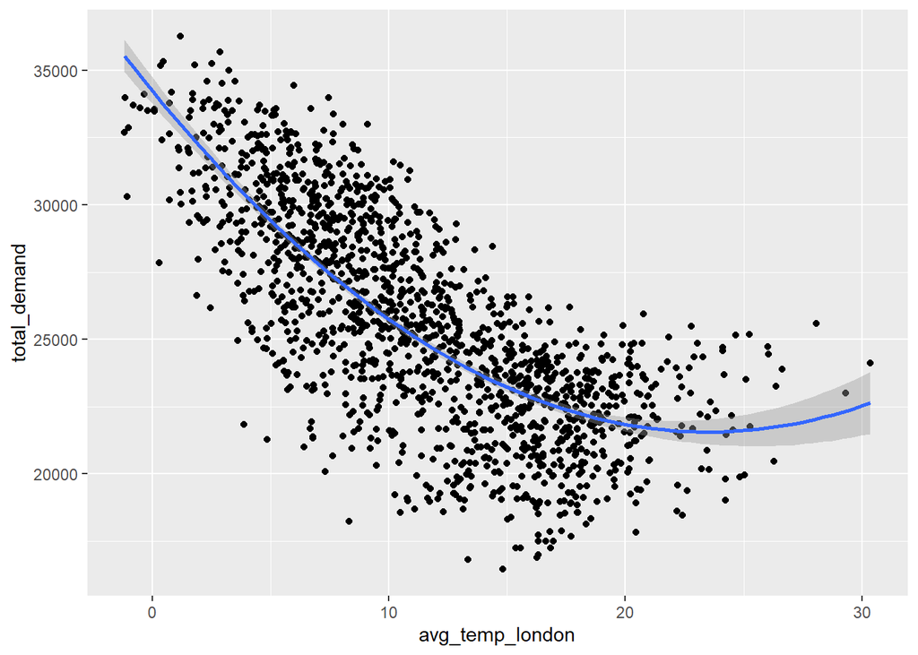

```r
data %>%
  mutate(avg_temp_london = (temp_london_00h + temp_london_06h + temp_london_12h + temp_london_18h)/4) %>%
  ggplot(aes(x=avg_temp_london, y=total_demand)) +
    geom_point() +
    stat_smooth(formula=y ~ poly(x, 2))
```

Generally linear and downwards trend with increase in sunshine duration.

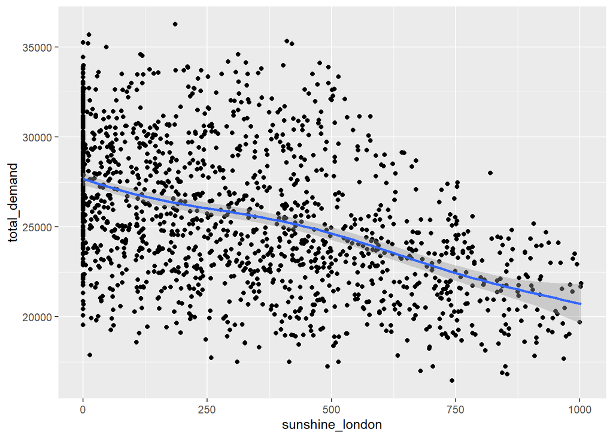

```r
data %>%
  ggplot(aes(x=sunshine_london, y=total_demand)) +
    geom_point() +
    stat_smooth()
```

When we compare weekends and weekdays, the demand on weekends are lower on average.

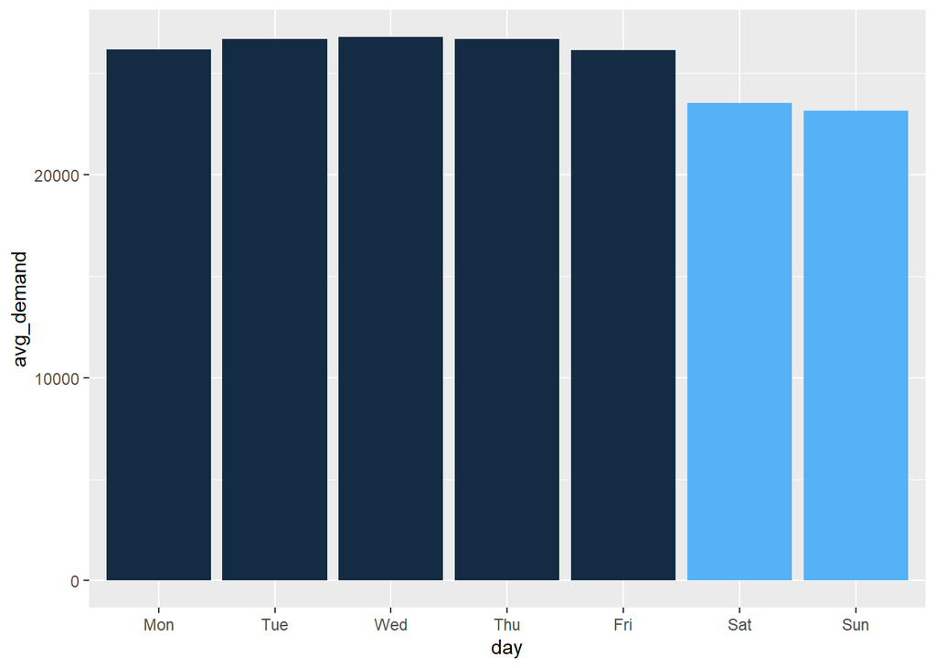

```r
# Ordering for days
days_name <- c("Mon" , "Tue" , "Wed" , "Thu" , "Fri" , "Sat" , "Sun")

# Comparing weekends and weekdays, on average weekends has lower demand
data %>%
  group_by(day_of_week, weekend) %>%
  summarise(avg_demand = mean(total_demand, na.rm=T), .groups="drop") %>%
  ggplot(aes(x=factor(day_of_week, levels = days_name), y=avg_demand)) +
    geom_bar(aes(fill=weekend), stat="identity", show.legend=F) +
    labs(x="day")
```

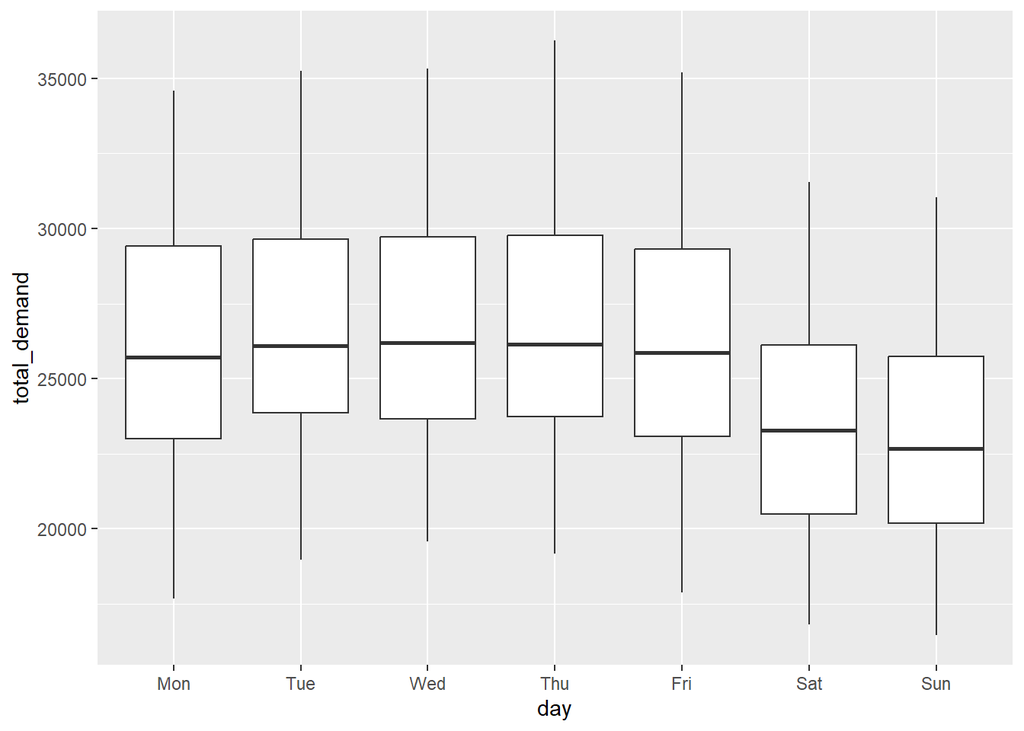

```r
# View seasonality across different days of the week
data %>%
  ggplot(aes(x=factor(day_of_week, levels = days_name), y=total_demand)) +
    geom_boxplot() + labs(x="day")
```

When viewing seasonality across the year, there is obvious pattern where summer months have lower demand. This likely is due to lower demand for heating.

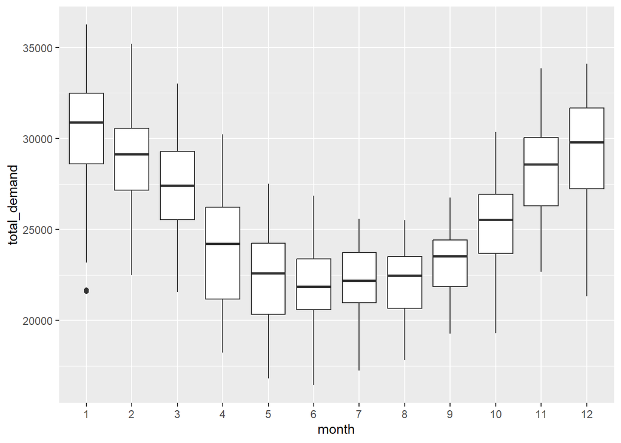

```r
# Get the month for each row
data <- data %>%
  mutate(month = month(date))

# View seasonality across different months
data %>%
  ggplot(aes(x=as.factor(month), y=total_demand)) +
    geom_boxplot() + labs(x="month")
```

Furthermore, the demand during holidays are generally lower than their non-holiday counterpart, except for Saturdays. This is likely due to a drop in electricity at commercial buildings during holidays.

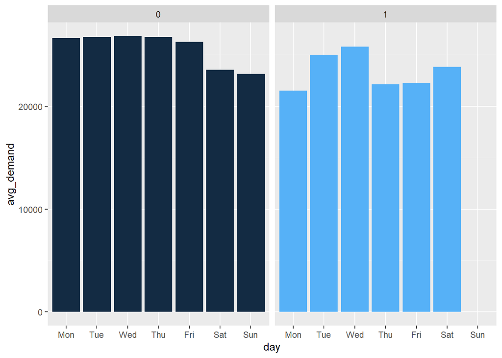

```r
# Split dataset based on holidays
data %>%
  group_by(day_of_week, holiday) %>%
  summarise(avg_demand = mean(total_demand, na.rm=T), .groups="drop") %>%
  ggplot(aes(x=factor(day_of_week, levels = days_name), y=avg_demand)) +
    geom_bar(aes(fill=holiday), stat="identity", show.legend=F) +
    facet_wrap(~ holiday) + labs(x="day")
```

View covid stringency and gas prices data.

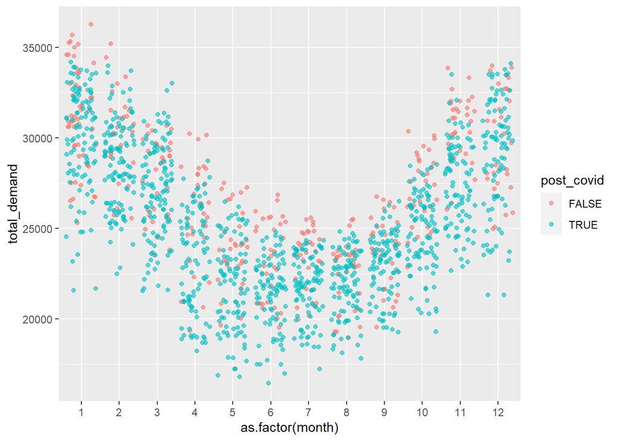

```r
# View covid stringency v.s. demand
data %>%
  mutate(post_covid = (stringency > 0)) %>%
  ggplot(aes(x=as.factor(month), y=total_demand, color=post_covid)) +
    geom_jitter(alpha=0.6)
```

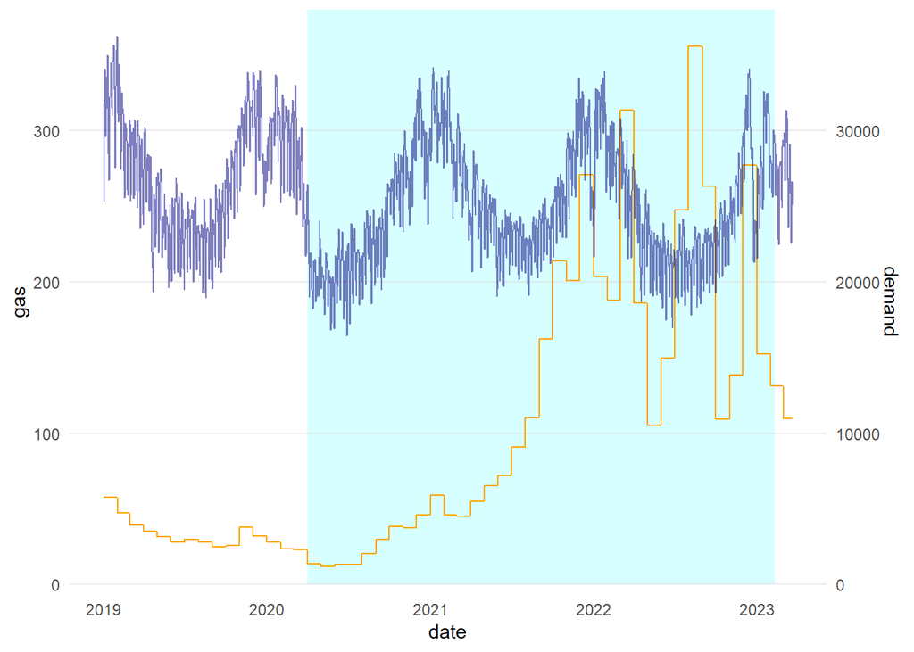

```r
# View demand v.s. gas prices
data %>%
  ggplot(aes(x=date)) +
    geom_rect(xmin=ymd(20200401), xmax=ymd(20230210),
              ymin=0, ymax=380, fill="lightblue", alpha=0.01) +
    geom_line(aes(y=avg_gas_index), color="orange") +
    geom_line(aes(y=total_demand/100), color="navy", alpha=0.5) +
    scale_y_continuous(name="gas",
                       sec.axis = sec_axis(~. * 100,
                                           name="demand")) +
    theme_minimal() +
    theme(panel.grid.minor=element_blank(),
          panel.grid.major.x=element_blank())
```

### C. Transform data

Add monthly dummy variables to capture monthly seasonality (as shown in boxplot above), apply log transformation to the demand and get second order polynomial for temperature.

```r
# Create dummy variables for each months by
# tabulating the month into matrix
data[month.abb] <-  t(sapply(data$month, tabulate, 12))

# Note: later to drop January (use as base)
# since num. dummy vars used should be (n-1)

# Apply log scale transformation and 2nd order polynomial
data <- data %>%
  mutate(ldemand = log(total_demand),
         temp_london_00h_sq = (temp_london_00h)**2,
         temp_london_06h_sq = (temp_london_06h)**2,
         temp_london_12h_sq = (temp_london_12h)**2,
         temp_london_18h_sq = (temp_london_18h)**2,
         temp_bristol_00h_sq = (temp_bristol_00h)**2,
         temp_bristol_06h_sq = (temp_bristol_06h)**2,
         temp_bristol_12h_sq = (temp_bristol_12h)**2,
         temp_bristol_18h_sq = (temp_bristol_18h)**2,
         temp_leeds_00h_sq = (temp_leeds_00h)**2,
         temp_leeds_06h_sq = (temp_leeds_06h)**2,
         temp_leeds_12h_sq = (temp_leeds_12h)**2,
         temp_leeds_18h_sq = (temp_leeds_18h)**2
  ) %>% filter(date >= ymd("2020-06-01"))

head(data)
```

```
## # A tibble: 6 × 48
##   date       temp_london_00h temp_london_06h temp_london_12h temp_london_18h
##   <date>               <dbl>           <dbl>           <dbl>           <dbl>
## 1 2020-06-01           10.2             17.3            22.3            18.0
## 2 2020-06-02           11.6             17.3            22.6            19.7
## 3 2020-06-03           15.1             18.3            15.6            13.4
## 4 2020-06-04           11.0             11.4            16.1            14.4
## 5 2020-06-05           10.2             10.3            13.2            11.0
## 6 2020-06-06            6.35            10.1            13.2            12.4
## # ℹ 43 more variables: temp_bristol_00h <dbl>, temp_bristol_06h <dbl>,
## #   temp_bristol_12h <dbl>, temp_bristol_18h <dbl>, temp_leeds_00h <dbl>,
## #   temp_leeds_06h <dbl>, temp_leeds_12h <dbl>, temp_leeds_18h <dbl>,
## #   sunshine_london <dbl>, sunshine_bristol <dbl>, sunshine_leeds <dbl>,
## #   total_demand <dbl>, day_of_week <chr>, weekend <dbl>, holiday <dbl>,
## #   stringency <dbl>, avg_gas_index <dbl>, month <dbl>, Jan <int>, Feb <int>,
## #   Mar <int>, Apr <int>, May <int>, Jun <int>, Jul <int>, Aug <int>, …
```

### D. Perform time-series analysis

**Visualise load demand time-series**

Capture as time series data using `ts()` and multi-seasonality time series data using `msts()` since we may observe multiple seasonality in months and years. From the STL decomposition, seasonality seems to be the highly significant factor in determining energy demand, while the effect from trend is clearly negligible.

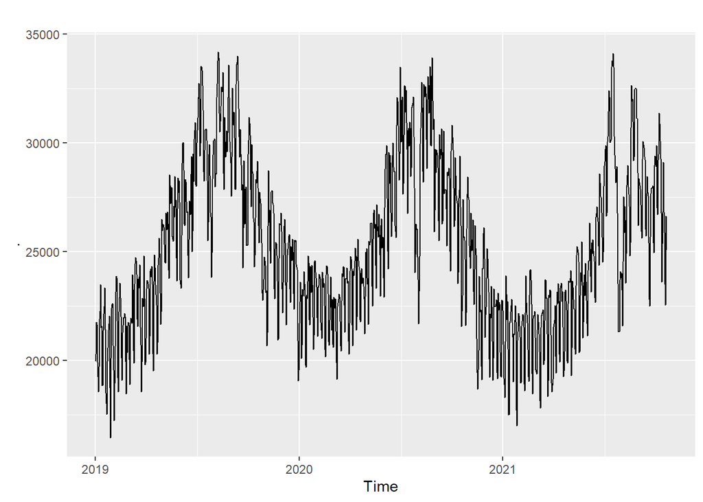

```r
##----- normal time-series conversion -----##
# Convert into timeseries data
ts_data <- ts(data, frequency = 365, start = decimal_date(ymd("2019-01-01")))

# Visualise the load demand across the period
ts_data[,17] %>%
  autoplot()
```

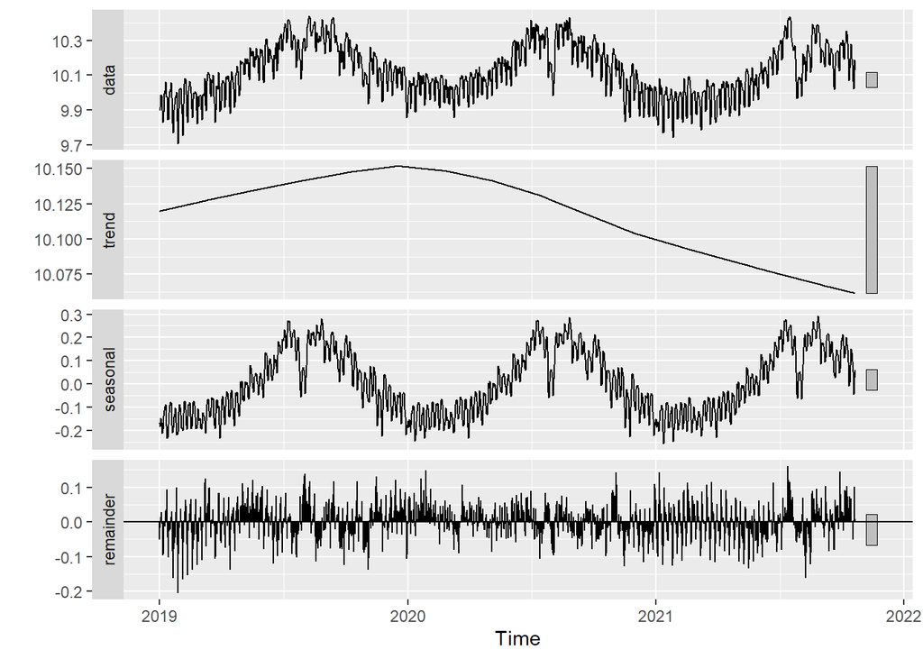

```r
# Decompose time series of log(demand) into trend and seasonality
# Seasonality is highly significant based on the grey bar on RHS
ts_data[,36] %>%
  stl(s.window = 7) %>%
  autoplot()
```

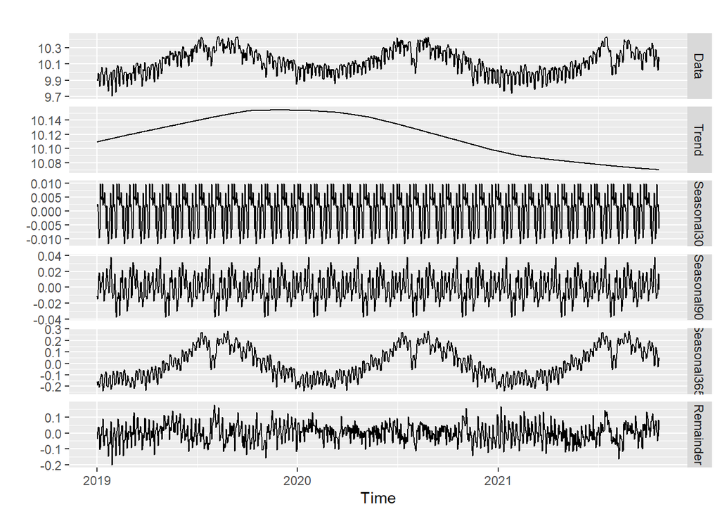

```r
##----- multi-seasonal time-series conversion -----##
# Convert into multi-seasonal time series with month, quarter and year seasonality
msts_data <- msts(data, seasonal.periods=c(30, 90, 365),
                   start=decimal_date(ymd("2019-01-01")))[,36]

# Decompose into multi-seasonality (month, quarter, year) and trend
msts_data %>%
  mstl(s.window="periodic") %>%
  autoplot()
```

```r
# Try fourier and multi-season timeseries (msts)
#msts(data, seasonal.periods=c(30, 90, 365), start=decimal_date(ymd("2019-01-01")))[,34] %>%
#  fourier(K=c(3, 3, 3))
```

**Stationarity test**

Check for stationarity using ADF, PP and KPSS test. From the three stationarity tests, we can see that PP and KPSS tests suggest stationarity in the data, while ADF tests has slightly conflicting result. By majority, we determine that the time-series data is stationary.

```r
# stationarity tests using Augmented Dicky-Fuller test
adf.test(ts_data[,36])
```

```
##
##  Augmented Dickey-Fuller Test
##
## data:  ts_data[, 36]
## Dickey-Fuller = -3.3611, Lag order = 10, p-value = 0.06015
## alternative hypothesis: stationary
```

```r
# p-value > 0.05, therefore fail to reject null hypothesis at 5% level
# data is non-stationary

# stationarity tests using Phillips-Perron test
pp.test(ts_data[,36])
```

```
##
##  Phillips-Perron Unit Root Test
##
## data:  ts_data[, 36]
## Dickey-Fuller Z(alpha) = -84.723, Truncation lag parameter = 7, p-value
## = 0.01
## alternative hypothesis: stationary
```

```r
# p-value < 0.01, therefore reject null hypothesis for unit root
# unit root is not present, and data is stationary

# stationarity tests using KPSS test
kpss.test(ts_data[,36])
```

```
##
##  KPSS Test for Level Stationarity
##
## data:  ts_data[, 36]
## KPSS Level = 0.54435, Truncation lag parameter = 7, p-value = 0.03168
```

```r
# p-value > 0.01, therefore fail to reject null hypothesis at 1% level
# hence data is stationary
```

**ACF/PACF**

From the ACF/PACF plot, we observe an AR(1) term and a seasonal ARMA(1, 4) with lag-7 first order of difference.

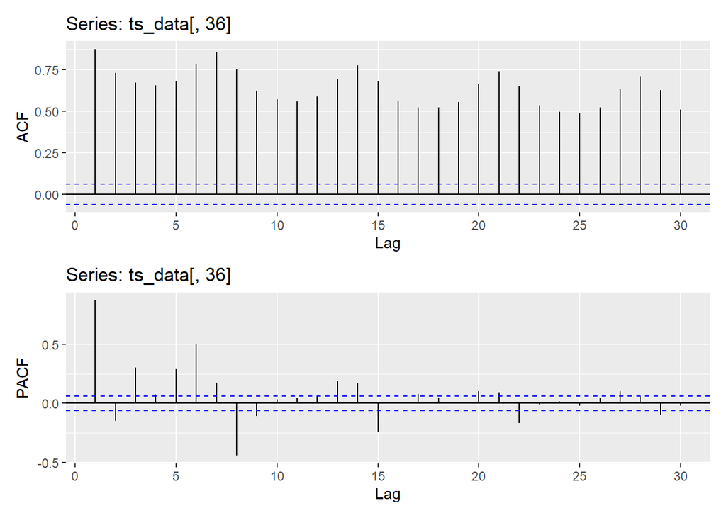

```r
p_acf0 <- ggAcf(ts_data[,36], lag.max=30)
p_pacf0 <- ggPacf(ts_data[,36], lag.max=30)

p_acf0 / p_pacf0
```

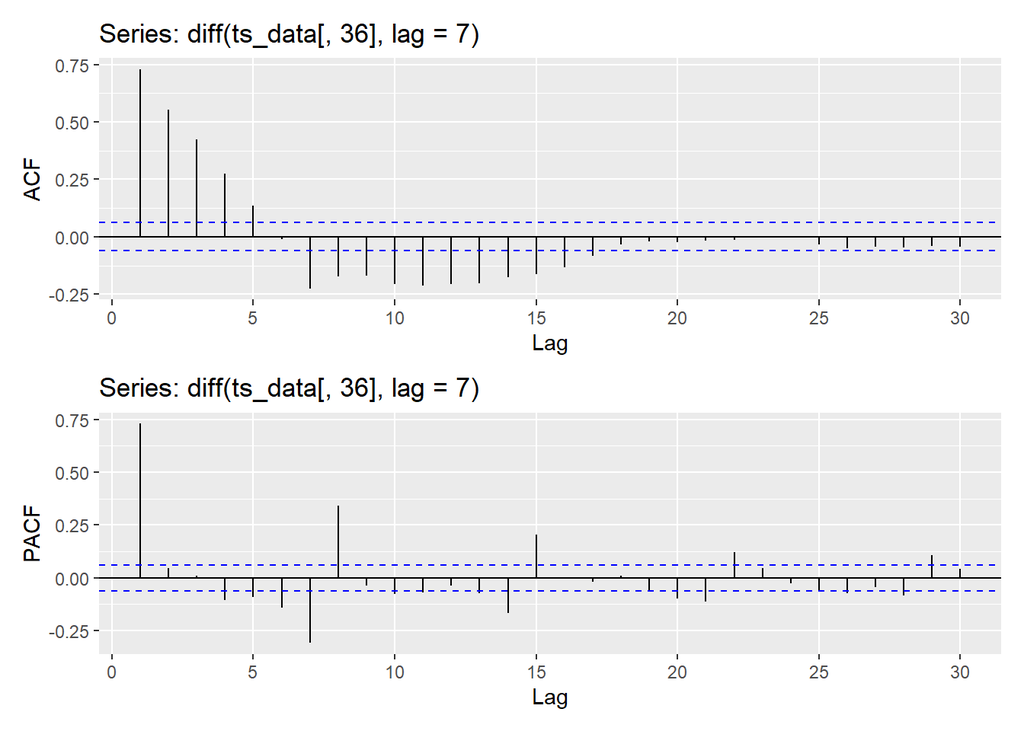

```r
# need to take diff

# taking diff lag=7 since ts repeats every 7 days
p_acf1 <- ggAcf(diff(ts_data[,36], lag=7), lag.max=30)
p_pacf1 <- ggPacf(diff(ts_data[,36], lag=7), lag.max=30)

p_acf1 / p_pacf1
```

```r
# MA model with Q = 4
# D = 1 (with lag 7)

# Check the order of differences
ndiffs(ts_data[,36]) ## d=1
```

```
## [1] 1
```

```r
nsdiffs(ts_data[,36]) ## D=1
```

```
## [1] 1
```

## III. Model fitting and selection

### A. Train-test split for model evaluation

Use 80% of the data as training, then evaluate the model with 20% remaining as test data.

```r
train_idx <- round(nrow(data) * 0.8)

train <- data[1:train_idx, ]
test <- data[(train_idx+1):(nrow(data)), ]

ts_train <- ts(train, frequency=365, start=c(0,1))
ts_test <- ts(test, frequency=365, start=c(0,train_idx + 1))
```

### B. ARIMA with Fourier Terms

For this, we Use `auto.arima` with Fourier approximation for seasonality. We select the best fourier approximation based on AICc and found that k = {3,1,2,3} gives the lowest AICc. We also find that this model passed the Ljung-Box test, showing sufficient model fit.

*Note: This fourier approximation will be used in the multivariate regression as well in the later section.*

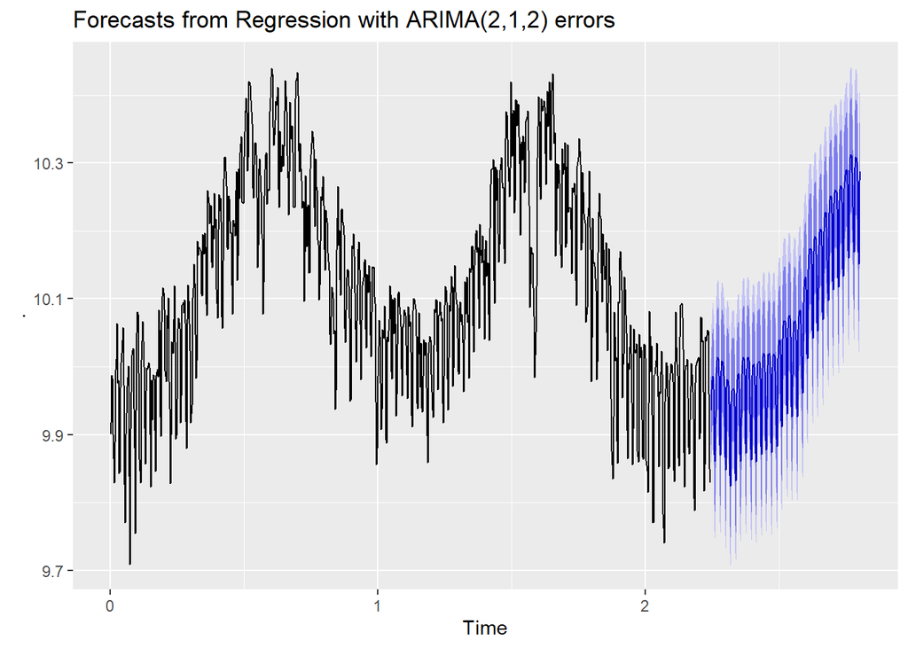

```r
# Run arima with different fourier max order K, select K with lowest AICc
msts_train <- msts(train, seasonal.periods=c(7, 30, 90, 365), start=c(0,1))
msts_test <- msts(test, seasonal.periods=c(7, 30, 90, 365), start=c(0,train_idx + 1))

#l <- c()
#i <- 0
#for (k1 in 3:3) {
#  for (k2 in 1:1) {
#    for (k3 in 2:5) {
#      for (k4 in 2:5) {
#        i <- i + 1
#        cat("i:", i, "k:", k1, k2, k3, k4)
#        freg <- fourier(msts_train[,34], K=c(k1, k2, k3, k4))
#        fit.arima <- msts_train[,34] %>% auto.arima(seasonal = FALSE, xreg=freg)
#        npar <- length(fit.arima$coef) + 1
#        nstar <- length(fit.arima$residuals) - fit.arima$arma[6] - fit.arima$arma[7] * fit.arima$arma[5]
#        aicc <- AIC(fit.arima) + 2 * npar * (nstar/(nstar - npar - 1) - 1)
#        l <- c(l,aicc)
#        cat("AICc:", aicc, "\n")
#      }
#    }
#  }
#}

# k: 3 1 2 3 AICc: -4305.603

#  cat("k:", k)
#  freg <- fourier(msts_train[,34], K=c(k)
#  fit.arima <- msts_train[,34] %>% auto.arima(seasonal = FALSE, xreg=freg)
#  npar <- length(fit.arima$coef) + 1
#  nstar <- length(fit.arima$residuals) - fit.arima$arma[6] - fit.arima$arma[7] * fit.arima$arma[5]
#  aicc <- AIC(fit.arima) + 2 * npar * (nstar/(nstar - npar - 1) - 1)
#  l <- c(l,aicc)

# we find k=2 gives the best AICc (for freq 365) and k: 3 1 2 3 AICc: -4305.603 (for msts periods 7, 30, 90, 365)
fit.arima <- msts_train[,36] %>% auto.arima(seasonal = FALSE, xreg=fourier(msts_train[,36], K=c(3, 1, 2, 3)))
forecast(fit.arima, h=(nrow(data) - train_idx), xreg=fourier(msts_test[,36], K=c(3, 1, 2, 3))) %>% autoplot()
```

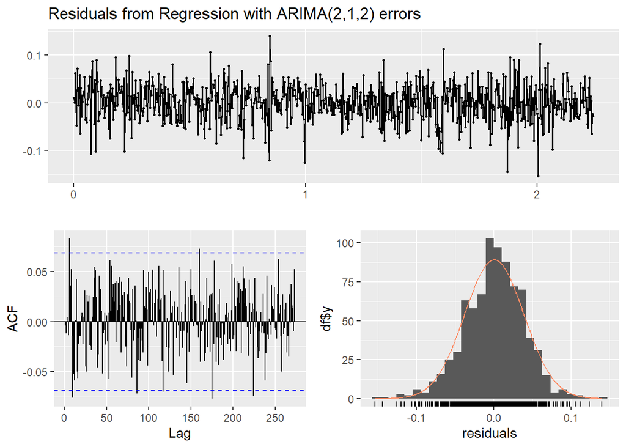

```
##
##  Ljung-Box test
##
## data:  Residuals from Regression with ARIMA(2,1,2) errors
## Q* = 157.32, df = 160, p-value = 0.5451
##
## Model df: 4.   Total lags used: 164
```

```r
checkresiduals(fit.arima)
```

```r
## Passed Ljung-Box test, model fit is sufficient

rmse_arima <- accuracy(forecast(fit.arima, h=(nrow(data) - train_idx), xreg=fourier(msts_test[,36], K=c(3, 1, 2, 3))), msts_test[,36])[4]
accuracy(forecast(fit.arima, h=(nrow(data) - train_idx), xreg=fourier(msts_test[,36], K=c(3, 1, 2, 3))), msts_test[,36])
```

```
##                        ME      RMSE        MAE         MPE      MAPE      MASE
## Training set 0.0005312939 0.0385225 0.02991795 0.003950368 0.2960615 0.3484087
## Test set     0.0926168531 0.1453777 0.11120248 0.905519277 1.0893319 1.2950059
##                      ACF1 Theil's U
## Training set -0.003880518        NA
## Test set      0.922652298  2.061113
```

### C. STLF model

We note that the common HW-ETS model does not work with multi-seasonal long-period time-series data. Hence we use STLF model which incorporates STL (seasonal and trend decomposition) into exponential smoothing (ETS). Although it failed the Ljung-Box test, the forecast shows decent performance.

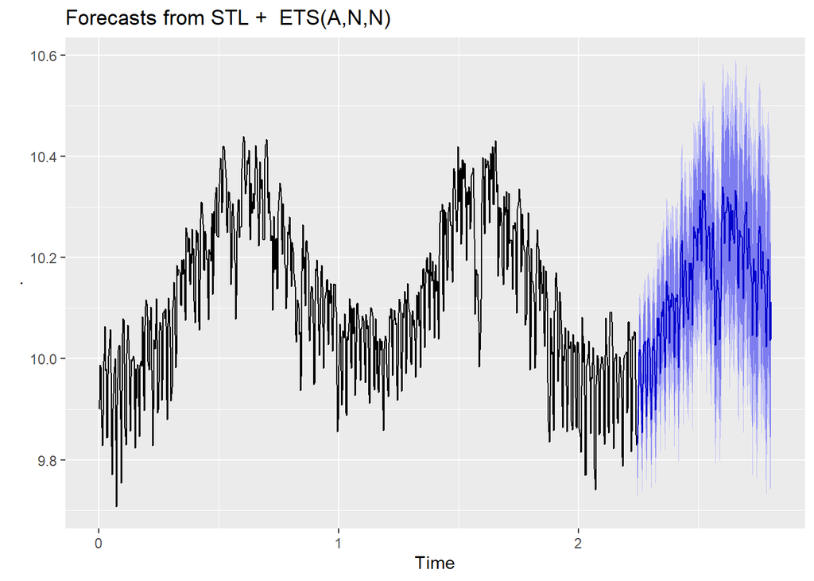

```r
fit.stlf <- ts_train[,36] %>% stlf(biasadj=TRUE)
forecast(fit.stlf, h=(nrow(data) - train_idx)) %>% autoplot()
```

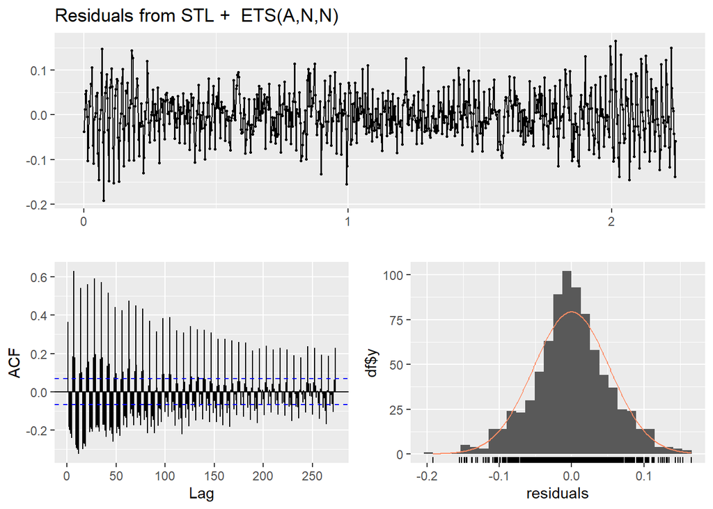

```
##
##  Ljung-Box test
##
## data:  Residuals from STL +  ETS(A,N,N)
## Q* = 6762.4, df = 162, p-value < 2.2e-16
##
## Model df: 2.   Total lags used: 164
```

```r
checkresiduals(fit.stlf)
```

```r
## Failed Ljung-Box test, poor model fit

rmse_sltf <- accuracy(forecast(fit.stlf, h=(nrow(data) - train_idx)), ts_test[,36])[4]
accuracy(forecast(fit.stlf, h=(nrow(data) - train_idx)), ts_test[,36])
```

```
##                         ME       RMSE        MAE          MPE      MAPE
## Training set -0.0002237694 0.05263361 0.04024915 -0.004773173 0.3994507
## Test set      0.0060648701 0.09362437 0.07480510  0.052682611 0.7368559
##                   MASE      ACF1 Theil's U
## Training set 0.4687205 0.3649151        NA
## Test set     0.8711411 0.5263500  1.341764
```

### D. Multivariate linear regression (MLR)

```r
# Check for variable selection using AIC
train.full <- lm(ldemand ~ temp_london_00h + temp_london_06h +
             temp_london_12h + temp_london_18h +
             temp_bristol_00h + temp_bristol_06h +
             temp_bristol_12h + temp_bristol_18h +
             temp_leeds_00h + temp_leeds_06h +
             temp_leeds_12h + temp_leeds_18h +
             sunshine_london + sunshine_bristol + sunshine_leeds +
             temp_london_00h_sq + temp_london_06h_sq +
             temp_london_12h_sq + temp_london_18h_sq +
             temp_bristol_00h_sq + temp_bristol_06h_sq +
             temp_bristol_12h_sq + temp_bristol_18h_sq +
             temp_leeds_00h_sq + temp_leeds_06h_sq +
             temp_leeds_12h_sq + temp_leeds_18h_sq +
             ## added average gas prices (monthly) and covid stringency
             weekend + holiday + avg_gas_index + stringency +
             Feb + Mar + Apr + May + Jun + Jul +
             Aug + Sep + Oct + Nov + Dec,
           data = na.omit(train))
train.null <- lm(ldemand ~ 1, data = na.omit(train))

step(train.null, scope = list(lower=train.null, upper=train.full), direction="forward", trace=FALSE)
```

```
##
## Call:
## lm(formula = ldemand ~ temp_london_12h + weekend + temp_london_12h_sq +
##     sunshine_bristol + holiday + Jun + temp_london_06h + Apr +
##     May + Jul + Aug + Sep + sunshine_london + temp_london_06h_sq +
##     Mar + Oct + stringency + temp_leeds_18h_sq + temp_leeds_06h +
##     Feb + temp_london_00h_sq + sunshine_leeds + temp_leeds_12h_sq +
##     temp_bristol_06h + temp_leeds_06h_sq + temp_bristol_12h_sq +
##     temp_london_00h + avg_gas_index, data = na.omit(train))
##
## Coefficients:
##         (Intercept)      temp_london_12h              weekend
##           1.043e+01           -4.017e-03           -1.333e-01
##  temp_london_12h_sq     sunshine_bristol              holiday
##           6.104e-05           -2.939e-05           -1.316e-01
##                 Jun      temp_london_06h                  Apr
##          -1.875e-01           -5.255e-03           -1.207e-01
##                 May                  Jul                  Aug
##          -1.310e-01           -1.740e-01           -1.730e-01
##                 Sep      sunshine_london   temp_london_06h_sq
##          -1.227e-01           -5.648e-05            4.348e-05
##                 Mar                  Oct           stringency
##          -5.968e-02           -5.126e-02            5.054e-04
##   temp_leeds_18h_sq       temp_leeds_06h                  Feb
##           2.668e-05           -8.330e-03           -2.309e-02
##  temp_london_00h_sq       sunshine_leeds    temp_leeds_12h_sq
##           3.583e-04           -3.120e-05            9.342e-05
##    temp_bristol_06h    temp_leeds_06h_sq  temp_bristol_12h_sq
##          -4.811e-03            2.437e-04            7.060e-05
##     temp_london_00h        avg_gas_index
##          -5.205e-03            5.987e-05
```

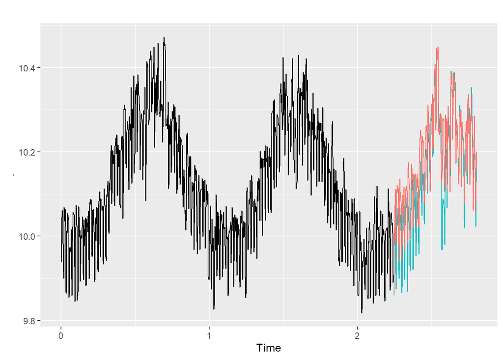

```r
train.reg <- lm(formula = ldemand ~ temp_london_12h + weekend + stringency +
    temp_london_12h_sq + sunshine_bristol + holiday + temp_london_06h +
    Apr + May + Jun + sunshine_leeds + Aug + Jul + Sep + Mar +
    sunshine_london + Oct + temp_london_06h_sq + temp_leeds_06h +
    temp_leeds_18h_sq + temp_london_00h_sq + temp_bristol_06h +
    temp_bristol_06h_sq + temp_london_00h + Feb + Dec + temp_bristol_12h_sq +
    temp_bristol_12h + temp_london_18h_sq + temp_leeds_12h_sq +
    avg_gas_index, data = na.omit(train))

ts(train.reg$fitted.values, frequency=365, end=c(0, train_idx)) %>%
   autoplot() +
   autolayer(ts(test[,36], frequency=365, start=c(0,train_idx +1)), show.legend=FALSE) +
   autolayer(ts(predict(train.reg, test), frequency=365, start=c(0,train_idx +1)), show.legend=FALSE)
```

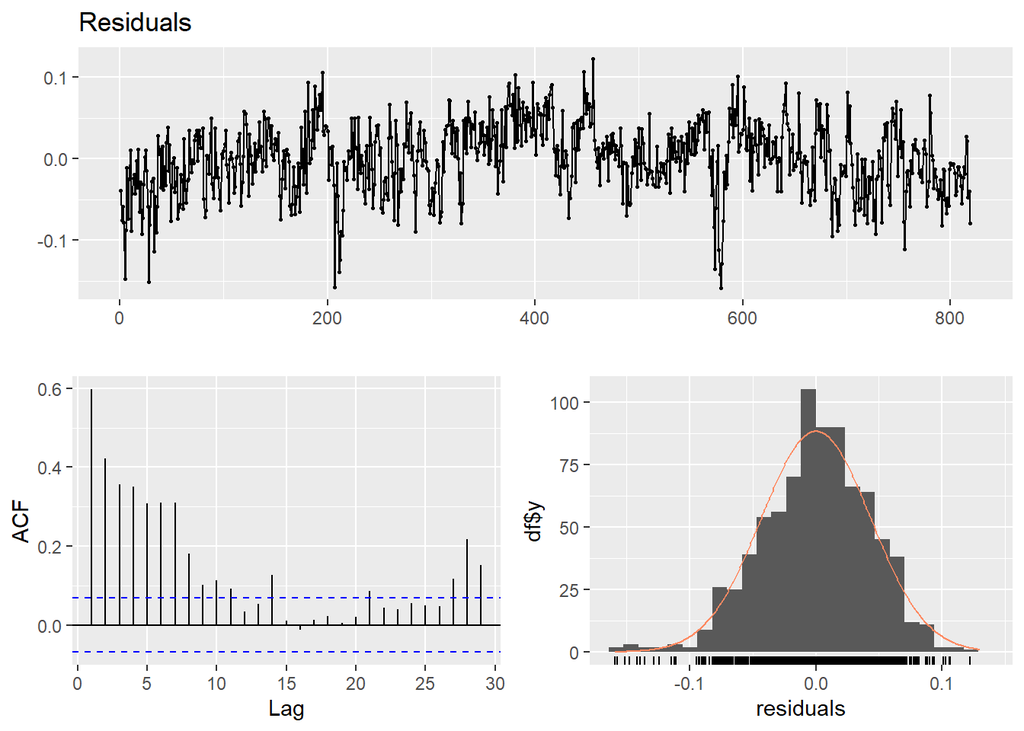

```
##
##  Breusch-Godfrey test for serial correlation of order up to 35
##
## data:  Residuals
## LM test = 404.05, df = 35, p-value < 2.2e-16
```

```r
checkresiduals(train.reg)
```

```r
# Significant trends and autocorrelation in residuals || AutoRegression maybe needed

rmse_mlr <- sqrt(mean((predict(train.reg, test) - as.matrix(test[,36])[,1])**2))
rmse_mlr
```

```
## [1] 0.06194382
```

### E. Neural network

```r
#set.seed(123)
#l <- c()
#for (k in 7:20) {
#  fit.nn <- neuralnet(
#     ldemand ~  temp_london_00h + temp_london_00h_sq + temp_london_06h + temp_london_06h_sq +
#                temp_london_12h + temp_london_12h_sq + temp_london_18h + temp_london_18h_sq +
#                temp_bristol_00h + temp_bristol_00h_sq + temp_bristol_06h + temp_bristol_06h_sq +
#                temp_bristol_12h + temp_bristol_12h_sq + temp_bristol_18h + temp_bristol_18h_sq +
#                temp_leeds_00h + temp_leeds_00h_sq + temp_leeds_06h + temp_leeds_06h_sq +
#                temp_leeds_12h + temp_leeds_12h_sq + temp_leeds_18h + temp_leeds_18h_sq +
#                sunshine_london + sunshine_bristol + sunshine_leeds +
#                weekend + holiday + stringency + avg_gas_index +
#                Feb + Mar + Apr + May + Jun + Jul + Aug + Sep + Oct + Nov + Dec,
#    data = na.omit(train),
#    hidden = k,
#    linear.output = TRUE,
#    err.fct = 'sse')
#
#  pred.nn <- neuralnet::compute(fit.nn, test)$net.result
#  act.nn <- test$ldemand
#
#  rmse_nn <- sqrt(sum((act.nn - pred.nn)**2 / nrow(test)))
#  l <- c(l, rmse_nn)
#  cat(k, rmse_nn, "\n")
#}

# hidden layers = 13 for best RMSE
```

The NN model prediction seems to be performing poorly as seen from the plot.

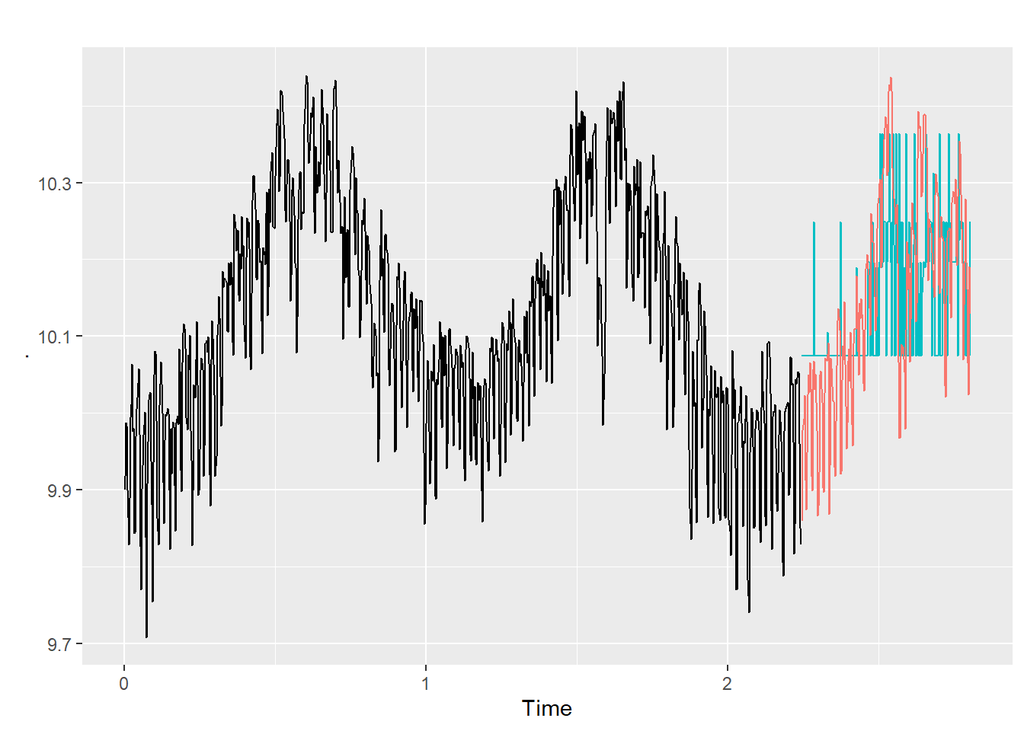

```r
set.seed(123)

# Set hidden layer to be 13 (obtained by minimising RMSE)
fit.nn <- neuralnet(
     ldemand ~  temp_london_00h + temp_london_00h_sq + temp_london_06h + temp_london_06h_sq +
                temp_london_12h + temp_london_12h_sq + temp_london_18h + temp_london_18h_sq +
                temp_bristol_00h + temp_bristol_00h_sq + temp_bristol_06h + temp_bristol_06h_sq +
                temp_bristol_12h + temp_bristol_12h_sq + temp_bristol_18h + temp_bristol_18h_sq +
                temp_leeds_00h + temp_leeds_00h_sq + temp_leeds_06h + temp_leeds_06h_sq +
                temp_leeds_12h + temp_leeds_12h_sq + temp_leeds_18h + temp_leeds_18h_sq +
                sunshine_london + sunshine_bristol + sunshine_leeds +
                weekend + holiday + stringency + avg_gas_index +
                Feb + Mar + Apr + May + Jun + Jul + Aug + Sep + Oct + Nov + Dec,
    data = na.omit(train),
    hidden = 13,
    linear.output = TRUE,
    err.fct = 'sse')

pred.nn <- neuralnet::compute(fit.nn, test)$net.result
act.nn <- test$ldemand
rmse_nn <- sqrt(sum((act.nn - pred.nn)**2 / nrow(test)))

##-- From the plot seems like NN is behaving funny tho i'm not sure why --##
msts_train[,36] %>%
  autoplot() +
  autolayer(ts(pred.nn[,1], frequency=365, start=c(0, train_idx+1)), show.legend=FALSE) +
  autolayer(ts(act.nn, frequency=365, start=c(0, train_idx+1)), show.legend=FALSE)
```

### F. Multivariate linear regression with Fourier terms (MLRF)

Extending MLR model with Fourier terms to further capture seasonality, we train the model and select the features using forward-step AIC.

```r
# Append cbind fourier transform on the data
msts_data <- msts(data, seasonal.periods=c(7, 30, 90, 365), start=c(0,1))
fdata <- cbind(data, fourier(msts_data[,36], K=c(3, 1, 2, 3)))
ftrain <- fdata[1:train_idx,]
ftest <- fdata[(train_idx + 1):nrow(fdata),]
# Check for variable selection using AIC
ftrain.full <- lm(ldemand ~ temp_london_00h + temp_london_06h +
                   temp_london_12h + temp_london_18h +
                   temp_bristol_00h + temp_bristol_06h +
                   temp_bristol_12h + temp_bristol_18h +
                   temp_leeds_00h + temp_leeds_06h +
                   temp_leeds_12h + temp_leeds_18h +
                   sunshine_london + sunshine_bristol + sunshine_leeds +
                   temp_london_00h_sq + temp_london_06h_sq +
                   temp_london_12h_sq + temp_london_18h_sq +
                   temp_bristol_00h_sq + temp_bristol_06h_sq +
                   temp_bristol_12h_sq + temp_bristol_18h_sq +
                   temp_leeds_00h_sq + temp_leeds_06h_sq +
                   temp_leeds_12h_sq + temp_leeds_18h_sq +
                   weekend + holiday + stringency + avg_gas_index +
                   Feb + Mar + Apr + May + Jun + Jul +
                   Aug + Sep + Oct + Nov + Dec +
                   `S1-7` + `C1-7` + `S2-7` + `C2-7` + `S3-7` + `C3-7` +
                   `S1-30` + `C1-30` + `S1-90` + `C1-90` + `S2-90` + `C2-90` +
                   `S1-365` + `C1-365` + `S2-365` + `C2-365` + `S3-365` + `C3-365`,
               data = na.omit(ftrain))
ftrain.null <- lm(ldemand ~ 1, data = na.omit(ftrain))

step(ftrain.null, scope = list(lower=ftrain.null, upper=ftrain.full), direction="forward", trace=FALSE)
```

[output not shown]

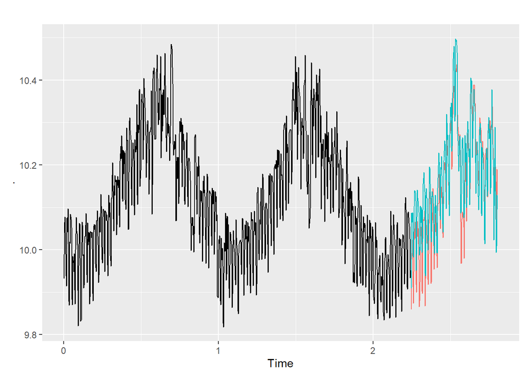

```r
train.freg <- lm(formula = ldemand ~ `C1-365` + weekend + holiday + temp_bristol_12h +
    stringency + temp_bristol_12h_sq + sunshine_leeds + temp_london_06h +
    `C3-365` + sunshine_london + temp_london_06h_sq + `S1-7` +
    `S2-90` + temp_leeds_18h_sq + temp_leeds_06h + May + temp_london_00h_sq +
    sunshine_bristol + temp_bristol_06h + temp_london_00h + `S1-30` +
    temp_london_18h_sq + `C2-90` + `C2-365` + `C3-7` + temp_london_18h +
    avg_gas_index + temp_bristol_06h_sq + `C1-7` + Apr + Nov +
    temp_leeds_12h_sq + `S3-7`, data = na.omit(ftrain))

ts(train.freg$fitted.values, frequency=365, end=c(0, train_idx)) %>%
   autoplot() +
   autolayer(ts(ftest[,36], frequency=365, start=c(0,train_idx +1)), show.legend=FALSE, na.rm=T) +
   autolayer(ts(predict(train.freg, ftest), frequency=365, start=c(0,train_idx +1), end=c(0, nrow(fdata))), show.legend=FALSE)
```

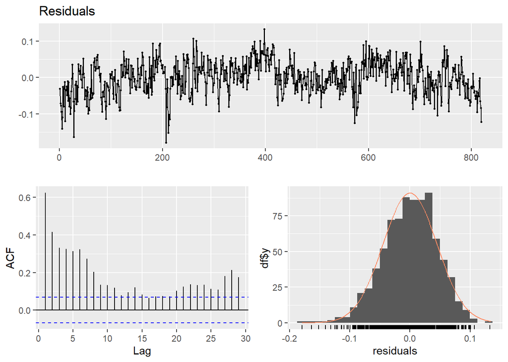

```
##
##  Breusch-Godfrey test for serial correlation of order up to 37
##
## data:  Residuals
## LM test = 394.58, df = 37, p-value < 2.2e-16
```

```r
## still bad ##
checkresiduals(train.freg)
```

```r
rmse_freg <- sqrt(mean((predict(train.freg, ftest) - as.matrix(ftest[,36])[,1])**2))
rmse_freg
```

```
## [1] 0.06048665
```

### G. Dynamic Harmonic Regression: ARIMA with X-term regressors (ARIMA-X)

An extension to our previous ARIMA model, we further fit regression terms that we selected from our MLR model.

```r
###--- Previous reg columns ---###
#columns_reg <- c("temp_london_00h", "temp_london_06h",
#                 "temp_london_12h", "temp_london_18h",
#                 "temp_bristol_12h", "temp_leeds_12h",
#                 "sunshine_london", "sunshine_bristol", "sunshine_leeds",
#                 "temp_london_00h_sq", "temp_london_06h_sq",
#                 "temp_london_12h_sq", "temp_london_18h_sq",
#                 "temp_bristol_12h_sq", "temp_leeds_12h_sq",
#                 "weekend", "holiday", "stringency")

###--- Use updated reg columns below ---###
columns_reg <- c("temp_london_12h", "weekend", "stringency", "temp_london_12h_sq", "sunshine_bristol",
                 "holiday", "temp_london_06h", "sunshine_leeds", "sunshine_london", "temp_london_06h_sq",
                 "temp_leeds_06h", "temp_leeds_18h_sq", "temp_london_00h_sq", "temp_bristol_06h",
                 "temp_bristol_06h_sq", "temp_london_00h", "temp_bristol_12h_sq", "temp_bristol_12h",
                 "temp_london_18h_sq", "temp_leeds_12h_sq", "avg_gas_index")

reg <- data[, columns_reg]
reg_train <- reg[1:train_idx, ]
reg_test <- reg[(train_idx + 1):nrow(data),]
```

```r
fit.arima.reg <- ts_train[, 36] %>% auto.arima(xreg = as.matrix(reg_train),  trace=TRUE)
```

```
##
##  Fitting models using approximations to speed things up...
##
##  Regression with ARIMA(2,1,2)             errors : -3292.399
##  Regression with ARIMA(0,1,0)             errors : -3217.707
##  Regression with ARIMA(1,1,0)             errors : Inf
##  Regression with ARIMA(0,1,1)             errors : Inf
##  Regression with ARIMA(0,1,0)             errors : Inf
##  Regression with ARIMA(1,1,2)             errors : Inf
##  Regression with ARIMA(2,1,1)             errors : Inf
##  Regression with ARIMA(3,1,2)             errors : Inf
##  Regression with ARIMA(2,1,3)             errors : -3316.033
##  Regression with ARIMA(1,1,3)             errors : Inf
##  Regression with ARIMA(3,1,3)             errors : -3290.665
##  Regression with ARIMA(2,1,4)             errors : Inf
##  Regression with ARIMA(1,1,4)             errors : Inf
##  Regression with ARIMA(3,1,4)             errors : Inf
##  Regression with ARIMA(2,1,3)             errors : Inf
##
##  Now re-fitting the best model(s) without approximations...
##
##  Regression with ARIMA(2,1,3)             errors : Inf
##  Regression with ARIMA(2,1,2)             errors : -3304.86
##
##  Best model: Regression with ARIMA(2,1,2)             errors
```

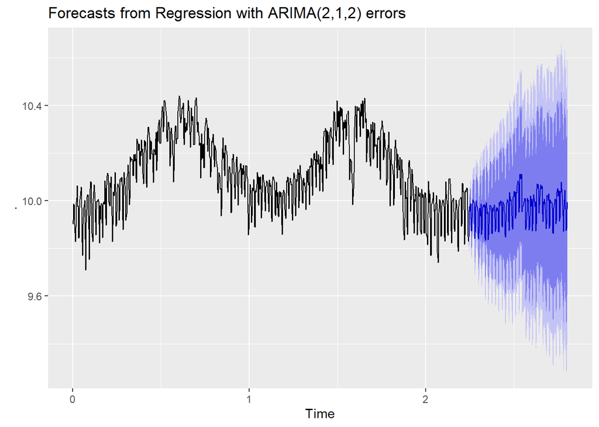

```r
forecast(fit.arima.reg, h=(nrow(data) - train_idx), xreg=as.matrix(reg_test)) %>% autoplot()
```

```r
rmse_arima.reg <- accuracy(forecast(fit.arima.reg, h=(nrow(data) - train_idx), xreg=as.matrix(reg_test)), ts_test[,36])[4]
accuracy(forecast(fit.arima.reg, h=(nrow(data) - train_idx), xreg=as.matrix(reg_test)), ts_test[,36])
```

```
##                         ME       RMSE        MAE          MPE      MAPE
## Training set -2.640345e-05 0.03099085 0.02443222 -0.001111785 0.2419416
## Test set      1.827086e-01 0.20507868 0.18270944  1.788895588 1.7889040
##                   MASE        ACF1 Theil's U
## Training set 0.2845249 -0.08378911        NA
## Test set     2.1277386  0.92921454    2.9131
```

```r
###----- ARIMA + xreg model comparisons -----###
## RMSE w/o stringency and gas prices - 0.13151529
## RMSE with stringency and gas prices - 0.10361727
```

### H. TBATS model

To increase our repertoires of models, we also attempt to use TBATS. We observe that TBATS captures the seasonality generally well.

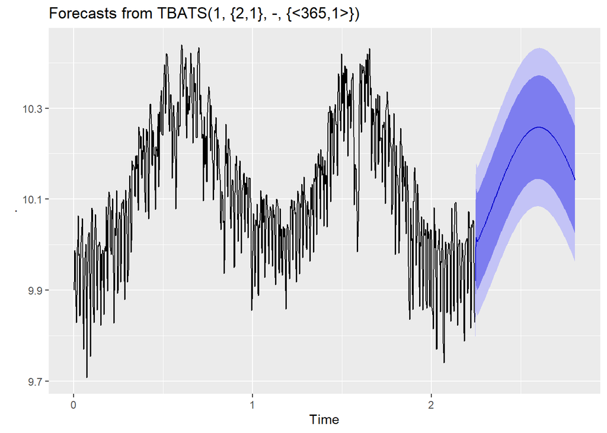

```r
train.tbats <- ts_train[,36] %>% tbats(biasadj=TRUE)
pred.tbats <- forecast(train.tbats, h=(nrow(data) - train_idx))

pred.tbats %>% autoplot()
```

```r
rmse_tbats <- accuracy(forecast(train.tbats, h=(nrow(data) - train_idx)), ts_test[,36])[4]
rmse_tbats ## it's actly not bad esp for short term and capturing the trend
```

```
## [1] 0.100875
```

## IV. Model comparison

### A. Plot of different model prediction

We visually compare the model forecasts in one plot. Some models clearly perform very poorly such as NN model and ARIMA seems to underpredict as compared to other models.

```r
actl_demand <- test[,36]
arima.reg_demand <- forecast(fit.arima.reg, h=(nrow(data) - train_idx), xreg=as.matrix(reg_test))$mean
arima.f_demand <- forecast(fit.arima, h=(nrow(data) - train_idx), xreg=fourier(msts_test[,34], K=c(3, 1, 2, 3)))$mean
stlf_demand <- forecast(fit.stlf, h=(nrow(data) - train_idx))$mean
mlr_demand <- predict(train.reg, test)
mlr.f_demand <- predict(train.freg, ftest)
nn_demand <- pred.nn[,1]
tbats_demand <- pred.tbats$mean

test_pred <- data.frame(actl_demand = actl_demand,
                        arima.reg_demand = arima.reg_demand,
                        arima.f_demand = arima.f_demand,
                        stlf_demand = stlf_demand,
                        mlr_demand = mlr_demand,
                        mlr.f_demand = mlr.f_demand,
                        nn_demand = nn_demand,
                        tbats_demand = tbats_demand)

# View data
test_pred[1:10,]
```

```
##      ldemand arima.reg_demand arima.f_demand stlf_demand mlr_demand
## 1   9.858916         9.849281       9.935096    9.831696   9.870092
## 2   9.977487         9.974948       9.966484    9.868694  10.019403
## 3   9.984231         9.955872       9.980387    9.948205   9.988541
## 4   9.991944         9.985135       9.985887   10.013052  10.073933
## 5  10.022694         9.989759       9.967027   10.018651  10.111373
## 6   9.912444         9.874779       9.870301   10.006608   9.988412
## 7   9.874061         9.874146       9.860659    9.944787   9.979896
## 8  10.023485         9.987721       9.989668    9.852979  10.110493
## 9  10.049933        10.003472      10.008618    9.950626  10.121220
## 10 10.026441         9.993883      10.013523   10.011604  10.104000
##    mlr.f_demand nn_demand tbats_demand
## 1      9.908491  10.07403     9.920166
## 2     10.087001  10.07403     9.995064
## 3     10.064144  10.07403    10.016188
## 4     10.086621  10.07403    10.012499
## 5     10.087740  10.07403    10.007500
## 6      9.986935  10.07403    10.007274
## 7      9.982297  10.07403    10.009881
## 8     10.102162  10.07403    10.012958
## 9     10.139458  10.07403    10.015677
## 10    10.138791  10.07403    10.018120
```

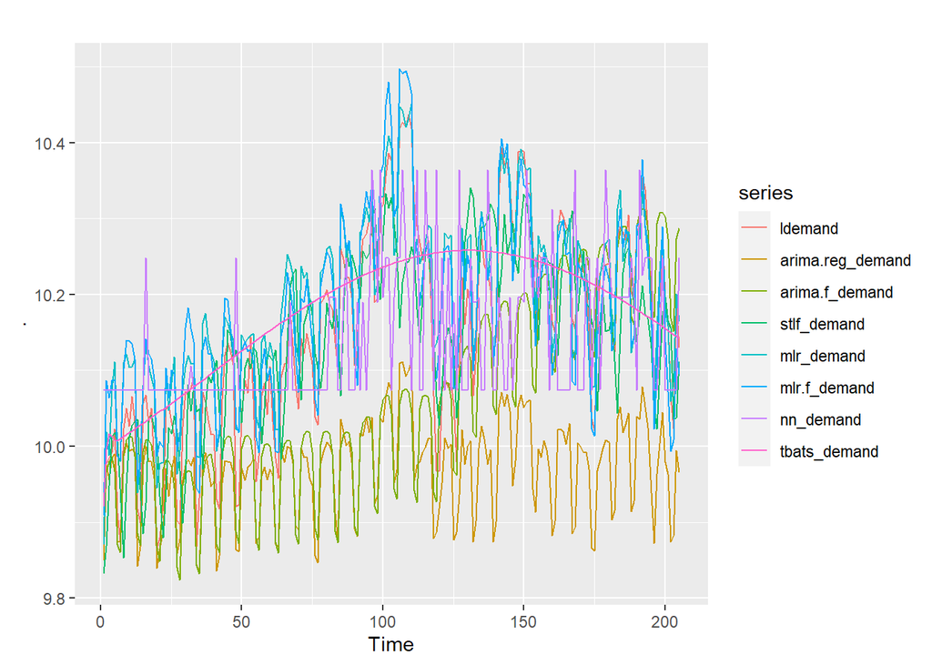

```r
# View plot
ts(test_pred[,]) %>% autoplot()
```

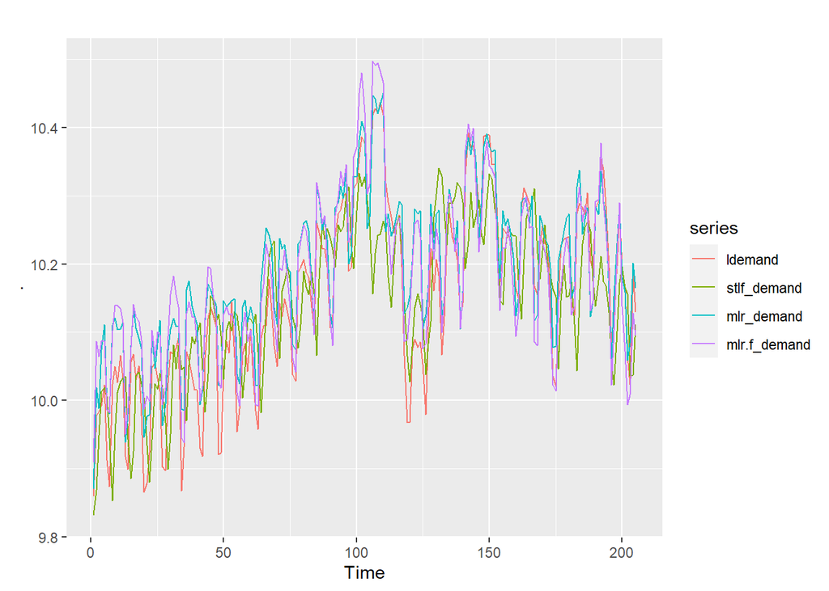

```r
# View only selected plots
ts(test_pred[, c(1,4:6)]) %>% autoplot()
```

### B. RMSE (forecast errors)

MLR model shows a strong performance in terms of RMSE.

```r
rmse_pred <-data.frame(arima_reg = rmse_arima.reg,
                        arima.f = rmse_arima,
                        sltf = rmse_sltf,
                        mlr = rmse_mlr,
                        mlr.f = rmse_freg,
                        nn = rmse_nn,
                        tbats = rmse_tbats)

as.data.frame(rbind(arima_reg = rmse_arima.reg,
                        arima.f = rmse_arima,
                        sltf = rmse_sltf,
                        mlr = rmse_mlr,
                        mlr.f = rmse_freg,
                        nn = rmse_nn,
                        tbats = rmse_tbats)) %>% rename(rmse=V1)
```

```
##                 rmse
## arima_reg 0.20507868
## arima.f   0.14537765
## sltf      0.09362437
## mlr       0.06194382
## mlr.f     0.06048665
## nn        0.12379508
## tbats     0.10087501
```

### C. Model Aggregation

Source: https://otexts.com/fpp2/combinations.html

> “The results have been virtually unanimous: combining multiple forecasts leads to increased forecast accuracy. In many cases one can make dramatic performance improvements by simply averaging the forecasts.”

We test various model combinations such as (1) pure average of all models, (2) simple average of selected 3 to 5 models, (3) weighted average of selected models.

```r
###---- All models ----###
combi_all_demand <- (arima.reg_demand + arima.f_demand + stlf_demand + mlr_demand + mlr.f_demand + nn_demand + tbats_demand) / 7

rmse_combi1 <- sqrt(mean((ts_test[,36] - combi_all_demand)**2))
rmse_combi1 ## RMSE at 0.09702 better than the original individual model on average
```

```
## [1] 0.0713136
```

```r
###---- Low RMSE (selected few) models ----###
combi_few_demand <- (arima.reg_demand + stlf_demand + mlr_demand + mlr.f_demand + tbats_demand) / 5

rmse_combi2 <- sqrt(mean((ts_test[,36] - combi_few_demand)**2))
rmse_combi2 ## RMSE at 0.09379 even better, but idk how to get the standard deviation like this ....
```

```
## [1] 0.06434532
```

```r
###---- Low RMSE (even less number) models ----###
combi_few_demand2 <- (arima.reg_demand + mlr_demand + mlr.f_demand) / 3

rmse_combi3 <- sqrt(mean((ts_test[,36] - combi_few_demand2)**2))
rmse_combi3 ## RMSE at 0.1001 no good, use 2nd combination
```

```
## [1] 0.0699843
```

```r
###---- What if we dont use ARIMA models ----###
combi_few_demand3 <- (stlf_demand + mlr_demand + mlr.f_demand + tbats_demand) / 4

rmse_combi4 <- sqrt(mean((ts_test[,36] - combi_few_demand3)**2))
rmse_combi4 ## RMSE at 0.09501 its not bad
```

```
## [1] 0.06245302
```

```r
###---- Weighted Combined Models based on RMSE ----###
inv_rmse_total <- 1/rmse_arima.reg + 1/rmse_sltf + 1/rmse_mlr + 1/rmse_freg + 1/rmse_tbats

combi_weighted_demand <- ((1/rmse_arima.reg) / inv_rmse_total * arima.reg_demand +
                          (1/rmse_sltf) / inv_rmse_total * stlf_demand +
                          (1/rmse_mlr) / inv_rmse_total * mlr_demand +
                          (1/rmse_freg) / inv_rmse_total * mlr.f_demand +
                          (1/rmse_tbats) / inv_rmse_total * tbats_demand)

rmse_combi_weighted <- sqrt(mean((ts_test[,36] - combi_weighted_demand)**2))
rmse_combi_weighted ## ROUND 5: RMSE best when weighted demand is used
```

```
## [1] 0.05542347
```

**We use combination of the following:**

- ARIMA with Regression
- STLF
- Multivariate regression (MLR)
- Multivariate regression with Fourier (MLRF)
- TBATS

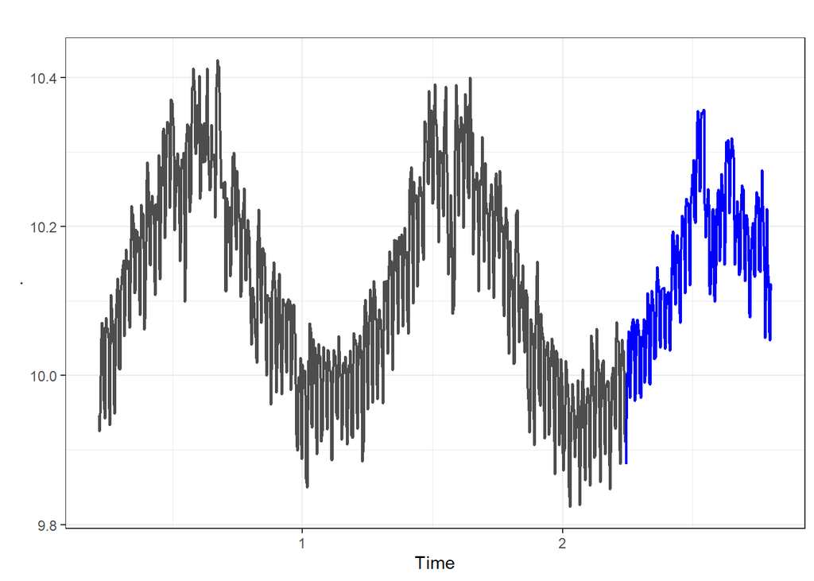

```r
stlf_limit <- 730
index_range1 <- (nrow(train)-stlf_limit+1):nrow(train)
index_range2 <- 1:stlf_limit

combi_fitted_demand <-(
  (1/rmse_arima.reg) / inv_rmse_total * fit.arima.reg$fitted[index_range1] +
    (1/rmse_sltf) / inv_rmse_total * fit.stlf$mean[index_range2] +
    (1/rmse_mlr) / inv_rmse_total * train.reg$fitted.values[index_range1] +
    (1/rmse_freg) / inv_rmse_total * train.freg$fitted.values[index_range1] +
    (1/rmse_tbats) / inv_rmse_total * train.tbats$fitted.values[index_range1])

#combi_weighted_demand
ts(combi_fitted_demand, frequency=360, start=c(0,nrow(train)-740)) %>% autoplot(color="grey30", linewidth=0.8) +
  autolayer(combi_weighted_demand, color="blue", linewidth=0.8) +
  theme_bw()
```

## V. Final Model: Forecast demand for ytd, tdy and tmr

### 1. Load and prep the latest data

```r
datafile <- "data_2023-03-22.csv"
predfile <- "variables_2023-03-22.csv"

pred.data <- read_csv(datafile)
pred.vars <- read_csv(predfile)
prepare <- function (data) {
  data <- data %>%
    filter(!is.na(date)) %>%
    mutate(month = month(date))
  data[month.abb] <-  t(sapply(data$month, tabulate, 12))
  data <- data %>%
    mutate(ldemand = log(total_demand),
           temp_london_00h_sq = (temp_london_00h)**2,
           temp_london_06h_sq = (temp_london_06h)**2,
           temp_london_12h_sq = (temp_london_12h)**2,
           temp_london_18h_sq = (temp_london_18h)**2,
           temp_bristol_00h_sq = (temp_bristol_00h)**2,
           temp_bristol_06h_sq = (temp_bristol_06h)**2,
           temp_bristol_12h_sq = (temp_bristol_12h)**2,
           temp_bristol_18h_sq = (temp_bristol_18h)**2,
           temp_leeds_00h_sq = (temp_leeds_00h)**2,
           temp_leeds_06h_sq = (temp_leeds_06h)**2,
           temp_leeds_12h_sq = (temp_leeds_12h)**2,
           temp_leeds_18h_sq = (temp_leeds_18h)**2
    )
  return(data)
}

pred.vars <- prepare(pred.vars)
pred.data <- prepare(pred.data)

ts.pred <- ts(pred.data, frequency = 365, start = decimal_date(ymd("2019-01-01")))
```

### 2. Prep the models

#### A. STLF Model

```r
model.stlf <- ts.pred[,36] %>% stlf()
fc_stlf <- forecast(model.stlf, h=3)
fc_stlf
```

```
##           Point Forecast    Lo 80    Hi 80    Lo 95    Hi 95
## 2023.2219       10.09945 10.01569 10.18321 9.971347 10.22755
## 2023.2247       10.10762 10.02279 10.19245 9.977887 10.23736
## 2023.2274       10.11760 10.03171 10.20348 9.986247 10.24895
```

#### B. MLR Model

```r
# Check for variable selection using AIC
full <- lm(ldemand ~ temp_london_00h + temp_london_06h +
             temp_london_12h + temp_london_18h +
             temp_bristol_00h + temp_bristol_06h +
             temp_bristol_12h + temp_bristol_18h +
             temp_leeds_00h + temp_leeds_06h +
             temp_leeds_12h + temp_leeds_18h +
             sunshine_london + sunshine_bristol + sunshine_leeds +
             temp_london_00h_sq + temp_london_06h_sq +
             temp_london_12h_sq + temp_london_18h_sq +
             temp_bristol_00h_sq + temp_bristol_06h_sq +
             temp_bristol_12h_sq + temp_bristol_18h_sq +
             temp_leeds_00h_sq + temp_leeds_06h_sq +
             temp_leeds_12h_sq + temp_leeds_18h_sq +
             weekend + holiday + stringency + avg_gas_index +
             Feb + Mar + Apr + May + Jun + Jul +
             Aug + Sep + Oct + Nov + Dec,
           data = na.omit(pred.data))
null <- lm(ldemand ~ 1, data = na.omit(pred.data))

step(null, scope = list(lower=null, upper=full), direction="forward", trace=FALSE)
```

```
##
## Call:
## lm(formula = ldemand ~ temp_london_12h + weekend + temp_london_12h_sq +
##     sunshine_bristol + holiday + temp_london_06h + stringency +
##     Apr + May + Jun + avg_gas_index + sunshine_london + temp_leeds_06h +
##     Nov + sunshine_leeds + Aug + Jul + Sep + Oct + Mar + temp_leeds_12h_sq +
##     temp_london_00h_sq + temp_london_00h + temp_bristol_06h +
##     temp_leeds_12h + Feb + temp_bristol_12h_sq, data = na.omit(pred.data))
##
## Coefficients:
##         (Intercept)      temp_london_12h              weekend
##           1.055e+01           -8.588e-03           -1.326e-01
##  temp_london_12h_sq     sunshine_bristol              holiday
##           2.286e-04           -3.812e-05           -1.550e-01
##     temp_london_06h           stringency                  Apr
##          -6.807e-03           -5.390e-04           -1.207e-01
##                 May                  Jun        avg_gas_index
##          -1.399e-01           -1.465e-01           -1.981e-04
##     sunshine_london       temp_leeds_06h                  Nov
##          -5.778e-05           -3.266e-03           -5.868e-03
##      sunshine_leeds                  Aug                  Jul
##          -5.080e-05           -1.257e-01           -1.240e-01
##                 Sep                  Oct                  Mar
##          -1.067e-01           -5.098e-02           -3.999e-02
##   temp_leeds_12h_sq   temp_london_00h_sq      temp_london_00h
##           2.613e-04            3.154e-04           -4.678e-03
##    temp_bristol_06h       temp_leeds_12h                  Feb
##          -4.016e-03           -4.787e-03           -1.199e-02
## temp_bristol_12h_sq
##           4.400e-05
```

```r
### Fit the MLR model
model.reg <- lm(formula = ldemand ~ temp_london_12h + weekend + temp_london_12h_sq +
    sunshine_bristol + holiday + temp_london_06h + stringency +
    Apr + May + Jun + avg_gas_index + sunshine_london + temp_leeds_06h +
    Nov + sunshine_leeds + Aug + Jul + Sep + Oct + Mar + temp_leeds_12h_sq +
    temp_london_00h_sq + temp_london_00h + temp_bristol_06h +
    temp_leeds_12h + Feb + temp_bristol_12h_sq, data = na.omit(pred.data))

fc_mlr <- predict(model.reg, pred.vars)
fc_mlr
```

```
##        1        2        3
## 10.20542 10.21855 10.22827
```

#### D. MLRF Model

```r
# Append cbind fourier transform on the data
msts.pred <- msts(pred.data, seasonal.periods=c(7, 30, 90, 365), start=c(0,1))
fpred.data <- cbind(pred.data, fourier(msts.pred[,36], K=c(3, 1, 2, 3)))

# Check for variable selection using AIC
f.full <- lm(ldemand ~ temp_london_00h + temp_london_06h +
                   temp_london_12h + temp_london_18h +
                   temp_bristol_00h + temp_bristol_06h +
                   temp_bristol_12h + temp_bristol_18h +
                   temp_leeds_00h + temp_leeds_06h +
                   temp_leeds_12h + temp_leeds_18h +
                   sunshine_london + sunshine_bristol + sunshine_leeds +
                   temp_london_00h_sq + temp_london_06h_sq +
                   temp_london_12h_sq + temp_london_18h_sq +
                   temp_bristol_00h_sq + temp_bristol_06h_sq +
                   temp_bristol_12h_sq + temp_bristol_18h_sq +
                   temp_leeds_00h_sq + temp_leeds_06h_sq +
                   temp_leeds_12h_sq + temp_leeds_18h_sq +
                   weekend + holiday + stringency + avg_gas_index +
                   Feb + Mar + Apr + May + Jun + Jul +
                   Aug + Sep + Oct + Nov + Dec +
                   `S1-7` + `C1-7` + `S2-7` + `C2-7` + `S3-7` + `C3-7` +
                   `S1-30` + `C1-30` + `S1-90` + `C1-90` + `S2-90` + `C2-90` +
                   `S1-365` + `C1-365` + `S2-365` + `C2-365` + `S3-365` + `C3-365`,
               data = na.omit(fpred.data))
f.null <- lm(ldemand ~ 1, data = na.omit(fpred.data))

step(f.null, scope = list(lower=f.null, upper=f.full), direction="forward", trace=FALSE)
```

```
##
## Call:
## lm(formula = ldemand ~ `C1-365` + weekend + temp_bristol_12h +
##     holiday + temp_bristol_12h_sq + sunshine_leeds + temp_london_06h +
##     temp_london_06h_sq + avg_gas_index + stringency + sunshine_london +
##     `C3-365` + `S1-7` + `S2-90` + temp_leeds_18h_sq + temp_leeds_06h +
##     sunshine_bristol + temp_london_00h_sq + Oct + Jun + `S3-7` +
##     `C2-7` + Apr + temp_leeds_12h_sq + Sep + temp_bristol_06h_sq +
##     temp_leeds_12h + temp_london_00h + `S1-30` + `S2-7` + `C1-90` +
##     Mar + Dec + Feb + Nov + `S3-365` + `C2-365`, data = na.omit(fpred.data))
##
## Coefficients:
##         (Intercept)             `C1-365`              weekend
##           1.049e+01            9.313e-02           -1.508e-01
##    temp_bristol_12h              holiday  temp_bristol_12h_sq
##          -6.381e-03           -1.492e-01            2.115e-04
##      sunshine_leeds      temp_london_06h   temp_london_06h_sq
##          -5.217e-05           -1.119e-02            1.580e-04
##       avg_gas_index           stringency      sunshine_london
##          -1.978e-04           -5.143e-04           -5.917e-05
##            `C3-365`               `S1-7`              `S2-90`
##          -2.251e-02           -3.273e-03           -9.174e-03
##   temp_leeds_18h_sq       temp_leeds_06h     sunshine_bristol
##          -3.731e-06           -2.728e-03           -3.212e-05
##  temp_london_00h_sq                  Oct                  Jun
##           3.292e-04           -4.135e-02           -2.000e-02
##              `S3-7`               `C2-7`                  Apr
##           8.073e-03           -1.359e-02           -4.068e-02
##   temp_leeds_12h_sq                  Sep  temp_bristol_06h_sq
##           3.158e-04           -3.038e-02           -1.650e-04
##      temp_leeds_12h      temp_london_00h              `S1-30`
##          -5.838e-03           -4.790e-03           -3.801e-03
##              `S2-7`              `C1-90`                  Mar
##          -4.678e-03            5.914e-03           -3.969e-02
##                 Dec                  Feb                  Nov
##          -2.120e-02           -2.419e-02           -2.755e-02
##            `S3-365`             `C2-365`
##          -6.238e-03           -8.079e-03
```

```r
model.freg <- lm(formula = ldemand ~ `C1-365` + weekend + temp_london_12h +
    holiday + temp_london_12h_sq + sunshine_bristol + stringency +
    avg_gas_index + temp_london_06h + sunshine_london + `C3-365` +
    sunshine_leeds + `S1-7` + temp_london_00h_sq + `S2-90` +
    temp_leeds_18h_sq + temp_leeds_06h + Oct + temp_london_00h +
    Jun + Apr + `S3-7` + Sep + temp_leeds_12h_sq + temp_bristol_06h +
    `C2-7` + `C1-90` + temp_leeds_12h + `S2-7` + temp_bristol_12h_sq +
    `S1-30`, data = na.omit(fpred.data))

# get fourier terms
msts.vars <- msts(pred.vars, seasonal.periods=c(7, 30, 90, 365), start=c(0,1))
fpred.vars <- cbind(pred.vars, fourier(msts.vars[,36], K=c(3, 1, 2, 3)))

fc_mlrf <- predict(model.freg, fpred.vars)
fc_mlrf
```

```
##        1        2        3
## 10.25386 10.26978 10.27454
```

#### D. TBATS Model

```r
model.tbats <- ts.pred[,36] %>% tbats(biasadj=TRUE)

fc_tbats <- forecast(model.tbats, h=3)
fc_tbats
```

```
##           Point Forecast    Lo 80    Hi 80    Lo 95    Hi 95
## 2023.2219       10.17311 10.10663 10.23959 10.07144 10.27478
## 2023.2247       10.22873 10.14845 10.30901 10.10595 10.35151
## 2023.2274       10.15666 10.07423 10.23909 10.03060 10.28272
```

#### E. ARIMA-X Model

```r
### Use columns form the MLR regressions, minus the months (seasonal terms)
reg_cols <- c("temp_london_12h", "weekend", "temp_london_12h_sq", "sunshine_bristol", "holiday", "temp_london_06h", "stringency", "avg_gas_index", "sunshine_london", "temp_leeds_06h", "sunshine_leeds", "temp_leeds_12h_sq", "temp_london_00h_sq", "temp_london_00h", "temp_bristol_06h", "temp_leeds_12h", "temp_bristol_12h_sq")


reg <- pred.data[, reg_cols]
reg_pred <- pred.vars[,reg_cols]
```

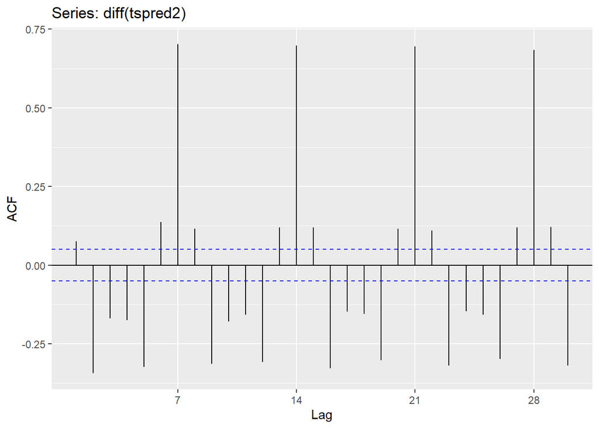

```r
tspred2 <- ts(pred.data, frequency=7, start=c(0,1))[,36]

ggAcf(diff(tspred2), lag.max=30)
```

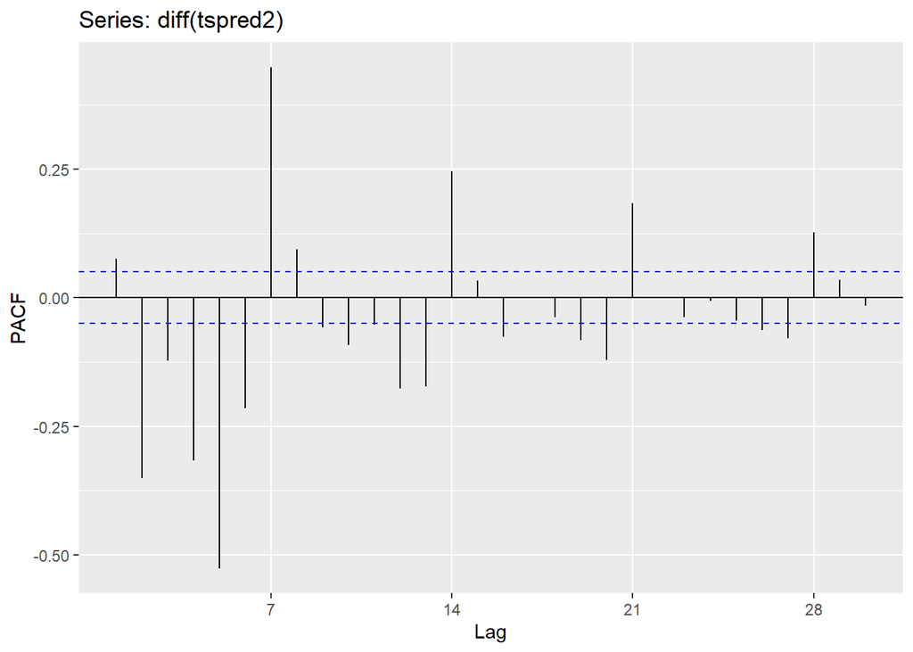

```r
ggPacf(diff(tspred2), lag.max=30)
```

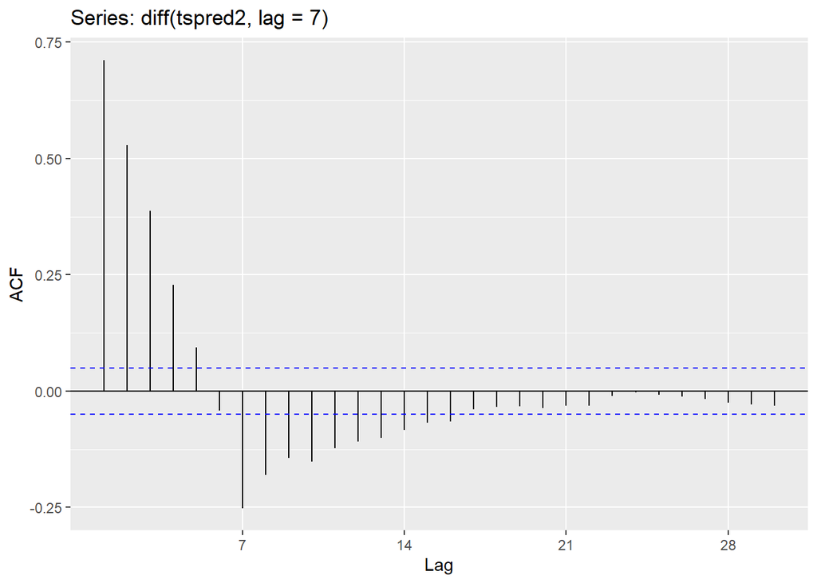

```r
ggAcf(diff(tspred2, lag=7), lag.max=30)
```

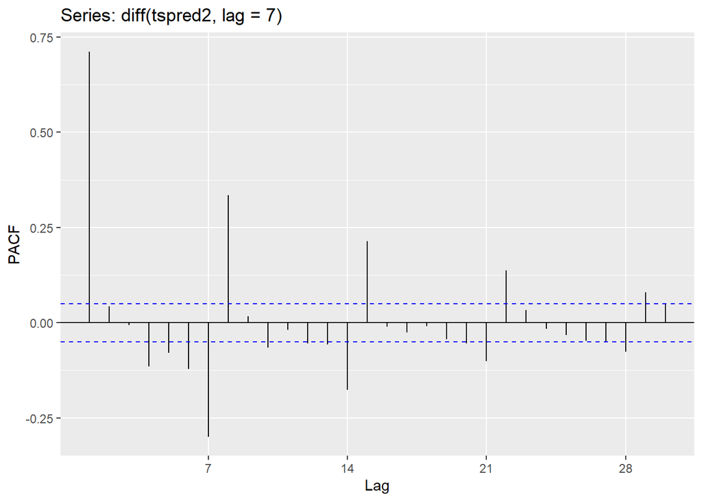

```r
ggPacf(diff(tspred2, lag=7), lag.max=30)
```

```r
#model.arima.reg <- ts.pred[, 36] %>% auto.arima(xreg = as.matrix(reg),  trace=TRUE)
model.arima.reg <- ts(pred.data, frequency=7, start=c(0,1))[,36] %>% Arima(order=c(1,1,1), seasonal=c(1,0,1), xreg = as.matrix(reg))
# ARIMA(1, 1, 1)(1, 0, 1) - AICc=-6380.66 <- this is lowest, tested against other p, q, P, Q parameters
# ARIMA(1, 1, 0)(1, 0, 1) - AICc=-6293.93
# ARIMA(0, 1, 0)(1, 0, 1) - AICc=-6248.11
# ARIMA(0, 1, 0)(1, 0, 1) - AICc=-6323.48
# ARIMA(2, 1, 1)(1, 0, 1) - AICc=-6330.99

# Check differencing required
ndiffs(ts.pred[,36])
```

```
## [1] 1
```

```r
nsdiffs(ts.pred[,36])
```

```
## [1] 1
```

```r
# Close enough
fc_arima.reg <- forecast(model.arima.reg, h=3, xreg=as.matrix(reg_pred))
fc_arima.reg
```

```
##          Point Forecast    Lo 80    Hi 80    Lo 95    Hi 95
## 220.1429       10.14067 10.10243 10.17891 10.08218 10.19916
## 220.2857       10.15366 10.10640 10.20092 10.08139 10.22594
## 220.4286       10.15254 10.10032 10.20476 10.07267 10.23240
```

```r
###
#avg_fitted_values <- (as.matrix(model.arima.reg$fitted) + as.matrix(model.stlf$fitted) + as.matrix(model.reg$fitted.values) + as.matrix(model.freg$fitted.values) + as.matrix(model.tbats$fitted.values))/5

avg_fitted_values <- (
  (1/rmse_arima.reg) / inv_rmse_total * as.matrix(model.arima.reg$fitted) +
    (1/rmse_sltf) / inv_rmse_total * as.matrix(model.stlf$fitted) +
    (1/rmse_mlr) / inv_rmse_total * as.matrix(model.reg$fitted.values) +
    (1/rmse_freg) / inv_rmse_total * as.matrix(model.freg$fitted.values) +
    (1/rmse_tbats) / inv_rmse_total * as.matrix(model.tbats$fitted.values)
  )

pred_residuals <- as.matrix(pred.data[,36]) - avg_fitted_values
sse <- sum(pred_residuals**2)
n <- length(pred_residuals)
sd <- sqrt(sse/(n-1))

mean(
as.matrix(pred.data[,36])[(length(avg_fitted_values)-7):length(avg_fitted_values),] / avg_fitted_values[(length(avg_fitted_values)-7):length(avg_fitted_values),]
)
```

```
## [1] 0.9957167
```

```r
###
avg_fc <- (as.matrix(fc_arima.reg$mean) + as.matrix(fc_stlf$mean) + as.matrix(fc_mlr) + as.matrix(fc_mlrf) + as.matrix(fc_tbats$mean))/5
avg_fc
```

```
##       [,1]
## 1 10.17450
## 2 10.19567
## 3 10.18592
```

```r
###
correction_factor <- pred.data[nrow(pred.data),36] / avg_fc[1]
corrected_fc2 <- correction_factor * avg_fc[2]
corrected_fc3 <- correction_factor * avg_fc[3]

###
cat("\nYTD's prediction:", avg_fc[1], "-->", exp(avg_fc[1]))
```

```
##
## YTD's prediction: 10.1745 --> 26225.86
```

```r
#cat("\nTDY's prediction:", avg_fc[2], "-->", exp(avg_fc[2]))
#cat("\nTMR's prediction:", avg_fc[3], "-->", exp(avg_fc[3]))
#cat("\nStandard Deviation:", sd)

cat("\nCorrection Multiplier:", correction_factor[1,1], "\n")
```

```
##
## Correction Multiplier: 0.9955532
```

```r
###
cat("\nTDY's prediction:", corrected_fc2[1,1], "-->", exp(corrected_fc2[1,1]))
```

```
##
## TDY's prediction: 10.15033 --> 25599.59
```

```r
cat("\nTMR's prediction:", corrected_fc3[1,1], "-->", exp(corrected_fc3[1,1]))
```

```
##
## TMR's prediction: 10.14063 --> 25352.31
```

```r
cat("\nStandard Deviation:", sd)
```

```
##
## Standard Deviation: 0.03762875
```